# Sampling distribution

## Bootstrap

If you want to know more about this method.

- There is a finance application from [Burns Statistics](http://www.burns-stat.com/documents/tutorials/the-statistical-bootstrap-and-other-resampling-methods-2/)
- [Quick R](http://www.statmethods.net/advstats/bootstrapping.html)

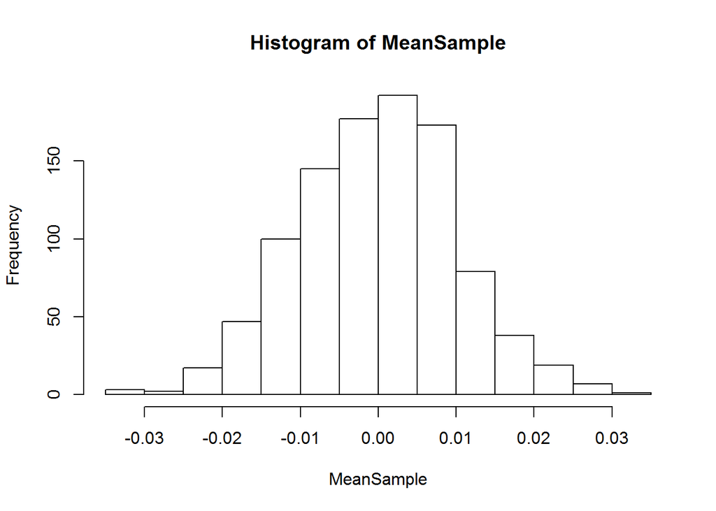

```r
n <- 1000 # sample size
MeanSample <- numeric(n)
for(i in 1:n){
  temp <- BACr[sample(length(BACr), length(BACr), replace = TRUE)]
  MeanSample[i] <- mean(temp, na.rm = TRUE)
}
hist(MeanSample)
```

```r
quantile(MeanSample, 0.025)
```

```
##       2.5%
## -0.0190047
```

```r
quantile(MeanSample, 0.975)
```

```
##    97.5%
## 0.020226
```

- n will determine the number of samples. That can be changed to 100,000 if you are willing to wait.
- Create a vector called `MeanSample` with a length of n
- Run a loop from 1 to n, with a temporary file called `temp`. `temp` will hold the random sample each time it is created by drawing random numbers from 1 to the length of `BACr` and using these as the index to draw the return value from `BACr`
- Calculate the mean from the sample and place the value in the $i^{th}$ position of `MeanSample`
- Plot the histogram of the calculated means
- Calculate the 2.5% and 97.5% values for confidence intervals using the `quantile` function.